# DISCRETE–Discrete Provision Optimal Allocation Solution (Line by Line)

# Objective

The california school dataset, the effect of teacher ratio on student scores.

# Load Packages and Data

## Load Dependencies

```r
rm(list = ls(all.names = TRUE))
options(knitr.duplicate.label = 'allow')
```

```r
library(dplyr)
library(tidyr)
library(tibble)
library(stringr)
library(broom)
library(ggplot2)
library(REconTools)

library(PrjOptiAlloc)

library(knitr)
library(kableExtra)
```

## Policy Parameters

```r
# 30 percent teacher at most per school, discretize floor as needed
fl_max_add_teacher_percent = 0.30
# 15 percent total additional of all teachers
fl_teacher_increase_percent = 0.15
```

## Load Data

1. *teachers*: is full-time-equivalent average number of teacher per district.
2. *enrl_tot*: is the enrollment average per district

```r
# Load Data
data(df_opt_caschool)
dfca <- df_opt_caschool

# Summarize
str(dfca)
```

```
## 'data.frame':    420 obs. of  18 variables:
##  $ X       : int  1 2 3 4 5 6 7 8 9 10 ...
##  $ distcod : int  75119 61499 61549 61457 61523 62042 68536 63834 62331 67306 ...
##  $ county  : Factor w/ 45 levels "Alameda","Butte",..: 1 2 2 2 2 6 29 11 6 25 ...
##  $ district: Factor w/ 409 levels "Ackerman Elementary",..: 362 214 367 134 270 53 152 383 263 93 ...
##  $ grspan  : Factor w/ 2 levels "KK-06","KK-08": 2 2 2 2 2 2 2 2 2 1 ...
##  $ enrltot : int  195 240 1550 243 1335 137 195 888 379 2247 ...
##  $ teachers: num  10.9 11.1 82.9 14 71.5 ...
##  $ calwpct : num  0.51 15.42 55.03 36.48 33.11 ...
##  $ mealpct : num  2.04 47.92 76.32 77.05 78.43 ...
##  $ computer: int  67 101 169 85 171 25 28 66 35 0 ...
##  $ testscr : num  691 661 644 648 641 ...
##  $ compstu : num  0.344 0.421 0.109 0.35 0.128 ...
##  $ expnstu : num  6385 5099 5502 7102 5236 ...
##  $ str     : num  17.9 21.5 18.7 17.4 18.7 ...
##  $ avginc  : num  22.69 9.82 8.98 8.98 9.08 ...
##  $ elpct   : num  0 4.58 30 0 13.86 ...
##  $ readscr : num  692 660 636 652 642 ...
##  $ mathscr : num  690 662 651 644 640 ...
```

```r
summary(dfca)
```

```
##        X            distcod              county
##  Min.   :  1.0   Min.   :61382   Sonoma     : 29
##  1st Qu.:105.8   1st Qu.:64308   Kern       : 27
##  Median :210.5   Median :67761   Los Angeles: 27
##  Mean   :210.5   Mean   :67473   Tulare     : 24
##  3rd Qu.:315.2   3rd Qu.:70419   San Diego  : 21
##  Max.   :420.0   Max.   :75440   Santa Clara: 20
##                                  (Other)    :272
##                       district     grspan       enrltot
##  Lakeside Union Elementary:  3   KK-06: 61   Min.   :   81.0
##  Mountain View Elementary :  3   KK-08:359   1st Qu.:  379.0
##  Jefferson Elementary     :  2               Median :  950.5
##  Liberty Elementary       :  2               Mean   : 2628.8
##  Ocean View Elementary    :  2               3rd Qu.: 3008.0
##  Pacific Union Elementary :  2               Max.   :27176.0
##  (Other)                  :406
##     teachers          calwpct          mealpct          computer
##  Min.   :   4.85   Min.   : 0.000   Min.   :  0.00   Min.   :   0.0
##  1st Qu.:  19.66   1st Qu.: 4.395   1st Qu.: 23.28   1st Qu.:  46.0
##  Median :  48.56   Median :10.520   Median : 41.75   Median : 117.5
##  Mean   : 129.07   Mean   :13.246   Mean   : 44.71   Mean   : 303.4
##  3rd Qu.: 146.35   3rd Qu.:18.981   3rd Qu.: 66.86   3rd Qu.: 375.2
##  Max.   :1429.00   Max.   :78.994   Max.   :100.00   Max.   :3324.0
##
##     testscr         compstu           expnstu          str
##  Min.   :605.5   Min.   :0.00000   Min.   :3926   Min.   :14.00
##  1st Qu.:640.0   1st Qu.:0.09377   1st Qu.:4906   1st Qu.:18.58
##  Median :654.5   Median :0.12546   Median :5215   Median :19.72
##  Mean   :654.2   Mean   :0.13593   Mean   :5312   Mean   :19.64
##  3rd Qu.:666.7   3rd Qu.:0.16447   3rd Qu.:5601   3rd Qu.:20.87
##  Max.   :706.8   Max.   :0.42083   Max.   :7712   Max.   :25.80
##
##      avginc           elpct           readscr         mathscr
##  Min.   : 5.335   Min.   : 0.000   Min.   :604.5   Min.   :605.4
##  1st Qu.:10.639   1st Qu.: 1.941   1st Qu.:640.4   1st Qu.:639.4
##  Median :13.728   Median : 8.778   Median :655.8   Median :652.5
##  Mean   :15.317   Mean   :15.768   Mean   :655.0   Mean   :653.3
##  3rd Qu.:17.629   3rd Qu.:22.970   3rd Qu.:668.7   3rd Qu.:665.9
##  Max.   :55.328   Max.   :85.540   Max.   :704.0   Max.   :709.5
##
```

```r
dfca %>% group_by(county) %>%
  summarise_if(is.numeric, funs(mean = mean), na.rm = TRUE)
```

```
## # A tibble: 45 x 16
##    county X_mean distcod_mean enrltot_mean teachers_mean calwpct_mean
##    <fct>   <dbl>        <dbl>        <dbl>         <dbl>        <dbl>
##  1 Alame~     1        75119          195          10.9         0.510
##  2 Butte     36        61486.        1152.         60.5        36.3
##  3 Calav~   233        61572          777          36.8        13.0
##  4 Contr~   299.       61738.        2726.        138.          3.51
##  5 El Do~   294.       61912.        1373.         69.5         6.73
##  6 Fresno   111        62250.         504.         26.4        21.1
##  7 Glenn    264.       62596          138.          6.58        7.11
##  8 Humbo~   240.       62888.         380.         20.6        17.8
##  9 Imper~   121.       63163.        1936          92.5        19.7
## 10 Inyo     252        63255         1510          73.3        10.3
## # ... with 35 more rows, and 10 more variables: mealpct_mean <dbl>,
## #   computer_mean <dbl>, testscr_mean <dbl>, compstu_mean <dbl>,
## #   expnstu_mean <dbl>, str_mean <dbl>, avginc_mean <dbl>, elpct_mean <dbl>,
## #   readscr_mean <dbl>, mathscr_mean <dbl>
```

```r
# Modifying and labeling etc.
# School characteristics are averaged across the district, don't know school count per district, implicitly assume the number of schools per district is the same.
# Some districts have larger and others smaller sized schools, ignoring within district variations.
dfca <- dfca %>%
          mutate(id = X) %>% select(-X) %>%
          select(id, everything()) %>%
          mutate(teachers = round(teachers),
                 enrltot = round(enrltot))

# Student and Teacher Ratio, str and stravg are almost identical
# use stravg because need to use enrltot and teachers variables later
dfca <- dfca %>% mutate(stravg = enrltot/teachers)
# view(dfca %>% select(stravg, str))

# Generate Discrete Version of continuous variables
# df_opt_birthwt <- df_opt_birthwt %>%
#     mutate(momwgtLowHigh = cut(lwt,
#                                breaks=c(-Inf, 129, Inf),
#                                labels=c("LW","HW"))) %>%
#     mutate(mombirthage = cut(age,
#                                breaks=c(-Inf, 24, Inf),
#                                labels=c("young","older"))) %>%
#     mutate(ftvm3 = cut(ftv,
#                                breaks=c(-Inf, 1, 2, Inf),
#                                labels=c("novisit","1visit","morevisit")))
```

# Regression with Data

## Tabulate

```r
# Tabulate groups, how many in each group, enough for group heterogeneity in effects?
dfca %>%
  group_by(county, grspan) %>%
  summarize(freq = n()) %>%
  pivot_wider(names_from = grspan, values_from = freq)
```

```
## # A tibble: 45 x 3
## # Groups:   county [45]
##    county       `KK-08` `KK-06`
##    <fct>          <int>   <int>
##  1 Alameda            1      NA
##  2 Butte              6      NA
##  3 Calaveras          1      NA
##  4 Contra Costa       7      NA
##  5 El Dorado         10      NA
##  6 Fresno            12      NA
##  7 Glenn              3      NA
##  8 Humboldt          14       3
##  9 Imperial           6      NA
## 10 Inyo               1      NA
## # ... with 35 more rows
```

## Regression Testing

Our estimation is based on regressing thest score on the student teacher ratio, from which we obtain a single estimate $\alpha$.

$$Y_i = A_i + \theta \cdot \frac{S_i}{T_i} + \epsilon$$

What is the marginal effect of adding one more unit?

What is the effect of adding an additional teacher?

We need to translate the estimate $\theta$ here into our equation’s allocation scale

$$Y_i \left(T_i\right) = A_i + \theta \cdot \frac{S_i}{T_i} + \epsilon\\
Y_i \left(T_i + 1\right) = A_i + \theta \cdot \frac{S_i}{T_i + 1} + \epsilon\\
EY_i \left(T_i + 1\right) - EY_i \left(T_i\right) = \theta \cdot S_i \cdot \left( \frac{1}{T_i + 1} - \frac{1}{T_i} \right)$$

```r
attach(dfca)
# Math, English, and Overall and str = student teacher ratio
summary(lm(mathscr ~ str))
```

```
##
## Call:
## lm(formula = mathscr ~ str)
##
## Residuals:
##     Min      1Q  Median      3Q     Max
## -44.615 -13.374  -0.828  12.728  52.711
##
## Coefficients:
##             Estimate Std. Error t value Pr(>|t|)
## (Intercept) 691.4174     9.3825  73.692  < 2e-16 ***
## str          -1.9386     0.4755  -4.077 5.47e-05 ***
## ---
## Signif. codes:  0 '***' 0.001 '**' 0.01 '*' 0.05 '.' 0.1 ' ' 1
##
## Residual standard error: 18.41 on 418 degrees of freedom
## Multiple R-squared:  0.03824,    Adjusted R-squared:  0.03594
## F-statistic: 16.62 on 1 and 418 DF,  p-value: 5.467e-05
```

```r
summary(lm(readscr ~ str))
```

```
##
## Call:
## lm(formula = readscr ~ str)
##
## Residuals:
##     Min      1Q  Median      3Q     Max
## -50.839 -14.479   1.121  14.495  44.370
##
## Coefficients:
##             Estimate Std. Error t value Pr(>|t|)
## (Intercept) 706.4485     9.9410  71.064  < 2e-16 ***
## str          -2.6210     0.5038  -5.202 3.09e-07 ***
## ---
## Signif. codes:  0 '***' 0.001 '**' 0.01 '*' 0.05 '.' 0.1 ' ' 1
##
## Residual standard error: 19.51 on 418 degrees of freedom
## Multiple R-squared:  0.06081,    Adjusted R-squared:  0.05856
## F-statistic: 27.06 on 1 and 418 DF,  p-value: 3.091e-07
```

```r
summary(lm(testscr ~ str))
```

```
##
## Call:
## lm(formula = testscr ~ str)
##
## Residuals:
##     Min      1Q  Median      3Q     Max
## -47.727 -14.251   0.483  12.822  48.540
##
## Coefficients:
##             Estimate Std. Error t value Pr(>|t|)
## (Intercept) 698.9330     9.4675  73.825  < 2e-16 ***
## str          -2.2798     0.4798  -4.751 2.78e-06 ***
## ---
## Signif. codes:  0 '***' 0.001 '**' 0.01 '*' 0.05 '.' 0.1 ' ' 1
##
## Residual standard error: 18.58 on 418 degrees of freedom
## Multiple R-squared:  0.05124,    Adjusted R-squared:  0.04897
## F-statistic: 22.58 on 1 and 418 DF,  p-value: 2.783e-06
```

```r
summary(lm(testscr ~ stravg))
```

```
##
## Call:
## lm(formula = testscr ~ stravg)
##
## Residuals:
##     Min      1Q  Median      3Q     Max
## -47.719 -14.504   0.435  12.510  48.536
##
## Coefficients:
##             Estimate Std. Error t value Pr(>|t|)
## (Intercept) 700.2132     9.3732  74.704  < 2e-16 ***
## stravg       -2.3458     0.4752  -4.937 1.15e-06 ***
## ---
## Signif. codes:  0 '***' 0.001 '**' 0.01 '*' 0.05 '.' 0.1 ' ' 1
##
## Residual standard error: 18.54 on 418 degrees of freedom
## Multiple R-squared:  0.05509,    Adjusted R-squared:  0.05283
## F-statistic: 24.37 on 1 and 418 DF,  p-value: 1.15e-06
```

```r
# Regress test score on str with student and teacher counts
summary(lm(testscr ~ enrltot + teachers + str))
```

```
##
## Call:
## lm(formula = testscr ~ enrltot + teachers + str)
##
## Residuals:
##     Min      1Q  Median      3Q     Max
## -48.726 -13.723   0.454  12.646  48.613
##
## Coefficients:
##               Estimate Std. Error t value Pr(>|t|)
## (Intercept) 691.053506  11.009245  62.770  < 2e-16 ***
## enrltot      -0.002793   0.003459  -0.808  0.41981
## teachers      0.048168   0.071289   0.676  0.49962
## str          -1.821241   0.563315  -3.233  0.00132 **
## ---
## Signif. codes:  0 '***' 0.001 '**' 0.01 '*' 0.05 '.' 0.1 ' ' 1
##
## Residual standard error: 18.53 on 416 degrees of freedom
## Multiple R-squared:  0.06047,    Adjusted R-squared:  0.0537
## F-statistic: 8.925 on 3 and 416 DF,  p-value: 9.632e-06
```

```r
summary(lm(testscr ~ enrltot + teachers + stravg))
```

```
##
## Call:
## lm(formula = testscr ~ enrltot + teachers + stravg)
##
## Residuals:
##     Min      1Q  Median      3Q     Max
## -48.699 -13.748   0.399  12.380  48.667
##
## Coefficients:
##               Estimate Std. Error t value Pr(>|t|)
## (Intercept) 692.964476  10.889054  63.639  < 2e-16 ***
## enrltot      -0.002493   0.003448  -0.723 0.470167
## teachers      0.042248   0.071067   0.594 0.552508
## stravg       -1.920592   0.557423  -3.445 0.000628 ***
## ---
## Signif. codes:  0 '***' 0.001 '**' 0.01 '*' 0.05 '.' 0.1 ' ' 1
##
## Residual standard error: 18.5 on 416 degrees of freedom
## Multiple R-squared:  0.06359,    Adjusted R-squared:  0.05683
## F-statistic: 9.416 on 3 and 416 DF,  p-value: 4.942e-06
```

```r
# Regress test score on str with covariates and county fe
summary(lm(testscr ~ factor(county) + calwpct + mealpct + computer + str - 1))
```

```
##
## Call:
## lm(formula = testscr ~ factor(county) + calwpct + mealpct + computer +
##     str - 1)
##
## Residuals:
##     Min      1Q  Median      3Q     Max
## -32.035  -4.981   0.188   5.137  23.819
##
## Coefficients:
##                                 Estimate Std. Error t value Pr(>|t|)
## factor(county)Alameda          7.072e+02  1.001e+01  70.621  < 2e-16 ***
## factor(county)Butte            7.009e+02  6.696e+00 104.678  < 2e-16 ***
## factor(county)Calaveras        6.980e+02  1.053e+01  66.301  < 2e-16 ***
## factor(county)Contra Costa     6.980e+02  6.391e+00 109.215  < 2e-16 ***
## factor(county)El Dorado        6.947e+02  6.152e+00 112.916  < 2e-16 ***
## factor(county)Fresno           6.959e+02  6.102e+00 114.043  < 2e-16 ***
## factor(county)Glenn            7.068e+02  7.953e+00  88.870  < 2e-16 ***
## factor(county)Humboldt         6.991e+02  5.687e+00 122.930  < 2e-16 ***
## factor(county)Imperial         6.960e+02  7.079e+00  98.314  < 2e-16 ***
## factor(county)Inyo             6.987e+02  1.044e+01  66.892  < 2e-16 ***
## factor(county)Kern             6.940e+02  6.010e+00 115.462  < 2e-16 ***
## factor(county)Kings            6.972e+02  6.456e+00 107.997  < 2e-16 ***
## factor(county)Lake             6.988e+02  8.372e+00  83.464  < 2e-16 ***
## factor(county)Lassen           6.988e+02  7.163e+00  97.556  < 2e-16 ***
## factor(county)Los Angeles      6.959e+02  6.328e+00 109.969  < 2e-16 ***
## factor(county)Madera           6.994e+02  6.788e+00 103.030  < 2e-16 ***
## factor(county)Marin            7.014e+02  5.893e+00 119.016  < 2e-16 ***
## factor(county)Mendocino        6.918e+02  1.047e+01  66.085  < 2e-16 ***
## factor(county)Merced           6.946e+02  6.380e+00 108.866  < 2e-16 ***
## factor(county)Monterey         6.887e+02  6.811e+00 101.116  < 2e-16 ***
## factor(county)Nevada           6.972e+02  6.024e+00 115.734  < 2e-16 ***
## factor(county)Orange           6.981e+02  6.579e+00 106.109  < 2e-16 ***
## factor(county)Placer           6.976e+02  6.325e+00 110.301  < 2e-16 ***
## factor(county)Riverside        6.946e+02  7.444e+00  93.310  < 2e-16 ***
## factor(county)Sacramento       6.900e+02  6.599e+00 104.565  < 2e-16 ***
## factor(county)San Benito       6.821e+02  7.252e+00  94.066  < 2e-16 ***
## factor(county)San Bernardino   6.935e+02  6.573e+00 105.507  < 2e-16 ***
## factor(county)San Diego        7.010e+02  5.944e+00 117.924  < 2e-16 ***
## factor(county)San Joaquin      6.852e+02  6.611e+00 103.656  < 2e-16 ***
```

[output cut: 11 more lines]

```
## factor(county)Trinity          7.259e+02  8.093e+00  89.691  < 2e-16 ***
## factor(county)Tulare           6.969e+02  6.260e+00 111.321  < 2e-16 ***
## factor(county)Tuolumne         6.970e+02  6.274e+00 111.095  < 2e-16 ***
## factor(county)Ventura          6.955e+02  6.811e+00 102.113  < 2e-16 ***
## factor(county)Yuba             7.121e+02  8.325e+00  85.532  < 2e-16 ***
## calwpct                        1.591e-02  6.949e-02   0.229  0.81898
## mealpct                       -5.909e-01  2.833e-02 -20.861  < 2e-16 ***
## computer                      -1.145e-04  1.172e-03  -0.098  0.92227
## str                           -8.483e-01  2.853e-01  -2.973  0.00314 **
## ---
## Signif. codes:  0 '***' 0.001 '**' 0.01 '*' 0.05 '.' 0.1 ' ' 1
##
## Residual standard error: 8.621 on 371 degrees of freedom
## Multiple R-squared:  0.9998, Adjusted R-squared:  0.9998
## F-statistic: 4.938e+04 on 49 and 371 DF,  p-value: < 2.2e-16
```

```r
summary(lm(testscr ~ factor(county) + calwpct + mealpct + computer + stravg - 1))
```

```
##
## Call:
## lm(formula = testscr ~ factor(county) + calwpct + mealpct + computer +
##     stravg - 1)
##
## Residuals:
##     Min      1Q  Median      3Q     Max
## -32.983  -4.907   0.122   4.895  23.816
##
## Coefficients:
##                                 Estimate Std. Error t value Pr(>|t|)
## factor(county)Alameda          7.074e+02  9.929e+00  71.249  < 2e-16 ***
## factor(county)Butte            7.013e+02  6.598e+00 106.285  < 2e-16 ***
## factor(county)Calaveras        6.984e+02  1.043e+01  66.943  < 2e-16 ***
## factor(county)Contra Costa     6.985e+02  6.297e+00 110.919  < 2e-16 ***
## factor(county)El Dorado        6.951e+02  6.053e+00 114.842  < 2e-16 ***
## factor(county)Fresno           6.965e+02  6.051e+00 115.100  < 2e-16 ***
## factor(county)Glenn            7.070e+02  7.793e+00  90.720  < 2e-16 ***
## factor(county)Humboldt         6.994e+02  5.572e+00 125.533  < 2e-16 ***
## factor(county)Imperial         6.965e+02  6.999e+00  99.518  < 2e-16 ***
## factor(county)Inyo             6.992e+02  1.038e+01  67.367  < 2e-16 ***
## factor(county)Kern             6.943e+02  5.882e+00 118.041  < 2e-16 ***
## factor(county)Kings            6.975e+02  6.324e+00 110.302  < 2e-16 ***
## factor(county)Lake             6.992e+02  8.305e+00  84.190  < 2e-16 ***
## factor(county)Lassen           6.992e+02  7.034e+00  99.402  < 2e-16 ***
## factor(county)Los Angeles      6.963e+02  6.201e+00 112.288  < 2e-16 ***
## factor(county)Madera           6.998e+02  6.695e+00 104.536  < 2e-16 ***
## factor(county)Marin            7.018e+02  5.803e+00 120.925  < 2e-16 ***
## factor(county)Mendocino        6.917e+02  1.031e+01  67.113  < 2e-16 ***
## factor(county)Merced           6.949e+02  6.250e+00 111.181  < 2e-16 ***
## factor(county)Monterey         6.891e+02  6.692e+00 102.973  < 2e-16 ***
## factor(county)Nevada           6.976e+02  5.923e+00 117.772  < 2e-16 ***
## factor(county)Orange           6.986e+02  6.457e+00 108.180  < 2e-16 ***
## factor(county)Placer           6.979e+02  6.178e+00 112.971  < 2e-16 ***
## factor(county)Riverside        6.950e+02  7.334e+00  94.766  < 2e-16 ***
## factor(county)Sacramento       6.904e+02  6.494e+00 106.314  < 2e-16 ***
## factor(county)San Benito       6.826e+02  7.182e+00  95.036  < 2e-16 ***
## factor(county)San Bernardino   6.939e+02  6.460e+00 107.421  < 2e-16 ***
## factor(county)San Diego        7.013e+02  5.823e+00 120.452  < 2e-16 ***
## factor(county)San Joaquin      6.855e+02  6.463e+00 106.062  < 2e-16 ***
```

[output cut: 11 more lines]

```
## factor(county)Trinity          7.265e+02  8.067e+00  90.061  < 2e-16 ***
## factor(county)Tulare           6.973e+02  6.128e+00 113.781  < 2e-16 ***
## factor(county)Tuolumne         6.974e+02  6.179e+00 112.866  < 2e-16 ***
## factor(county)Ventura          6.958e+02  6.678e+00 104.196  < 2e-16 ***
## factor(county)Yuba             7.125e+02  8.245e+00  86.421  < 2e-16 ***
## calwpct                        1.543e-02  6.941e-02   0.222  0.82425
## mealpct                       -5.902e-01  2.830e-02 -20.857  < 2e-16 ***
## computer                      -9.125e-05  1.171e-03  -0.078  0.93794
## stravg                        -8.700e-01  2.794e-01  -3.114  0.00199 **
## ---
## Signif. codes:  0 '***' 0.001 '**' 0.01 '*' 0.05 '.' 0.1 ' ' 1
##
## Residual standard error: 8.611 on 371 degrees of freedom
## Multiple R-squared:  0.9998, Adjusted R-squared:  0.9998
## F-statistic: 4.95e+04 on 49 and 371 DF,  p-value: < 2.2e-16
```

## Discrete Regression

Need to convert regression results to increment effect.

```r
# Store Regression Results
mt_model <- model.matrix( ~ factor(county) + calwpct + mealpct + computer + stravg)
rs_scr_on_str = lm(testscr ~ mt_model - 1)
print(summary(rs_scr_on_str))
```

```
##
## Call:
## lm(formula = testscr ~ mt_model - 1)
##
## Residuals:
##     Min      1Q  Median      3Q     Max
## -32.983  -4.907   0.122   4.895  23.816
##
## Coefficients:
##                                         Estimate Std. Error t value Pr(>|t|)
## mt_model(Intercept)                    7.074e+02  9.929e+00  71.249  < 2e-16
## mt_modelfactor(county)Butte           -6.114e+00  9.475e+00  -0.645  0.51914
## mt_modelfactor(county)Calaveras       -9.023e+00  1.224e+01  -0.737  0.46134
## mt_modelfactor(county)Contra Costa    -8.961e+00  9.225e+00  -0.971  0.33196
## mt_modelfactor(county)El Dorado       -1.231e+01  9.053e+00  -1.360  0.17461
## mt_modelfactor(county)Fresno          -1.094e+01  9.092e+00  -1.204  0.22950
## mt_modelfactor(county)Glenn           -4.135e-01  1.004e+01  -0.041  0.96717
## mt_modelfactor(county)Humboldt        -7.976e+00  8.912e+00  -0.895  0.37136
## mt_modelfactor(county)Imperial        -1.090e+01  9.435e+00  -1.156  0.24852
## mt_modelfactor(county)Inyo            -8.272e+00  1.223e+01  -0.677  0.49904
## mt_modelfactor(county)Kern            -1.308e+01  8.877e+00  -1.473  0.14159
## mt_modelfactor(county)Kings           -9.885e+00  9.159e+00  -1.079  0.28117
## mt_modelfactor(county)Lake            -8.203e+00  1.076e+01  -0.762  0.44647
## mt_modelfactor(county)Lassen          -8.230e+00  9.500e+00  -0.866  0.38688
## mt_modelfactor(county)Los Angeles     -1.113e+01  8.889e+00  -1.253  0.21112
## mt_modelfactor(county)Madera          -7.587e+00  9.494e+00  -0.799  0.42472
## mt_modelfactor(county)Marin           -5.658e+00  9.137e+00  -0.619  0.53610
## mt_modelfactor(county)Mendocino       -1.571e+01  1.225e+01  -1.282  0.20058
## mt_modelfactor(county)Merced          -1.251e+01  9.119e+00  -1.372  0.17094
## mt_modelfactor(county)Monterey        -1.832e+01  9.310e+00  -1.968  0.04986
## mt_modelfactor(county)Nevada          -9.845e+00  9.093e+00  -1.083  0.27967
## mt_modelfactor(county)Orange          -8.874e+00  9.109e+00  -0.974  0.33057
## mt_modelfactor(county)Placer          -9.481e+00  9.029e+00  -1.050  0.29437
## mt_modelfactor(county)Riverside       -1.238e+01  9.744e+00  -1.270  0.20484
## mt_modelfactor(county)Sacramento      -1.701e+01  9.395e+00  -1.810  0.07103
## mt_modelfactor(county)San Benito      -2.485e+01  9.961e+00  -2.494  0.01306
## mt_modelfactor(county)San Bernardino  -1.352e+01  9.127e+00  -1.482  0.13926
## mt_modelfactor(county)San Diego       -6.090e+00  8.885e+00  -0.685  0.49348
## mt_modelfactor(county)San Joaquin     -2.195e+01  9.351e+00  -2.347  0.01943
## mt_modelfactor(county)San Luis Obispo -8.300e+00  1.058e+01  -0.785  0.43324
```

[output cut: 60 more lines]

```
## mt_modelfactor(county)Trinity         .
## mt_modelfactor(county)Tulare
## mt_modelfactor(county)Tuolumne
## mt_modelfactor(county)Ventura
## mt_modelfactor(county)Yuba
## mt_modelcalwpct
## mt_modelmealpct                       ***
## mt_modelcomputer
## mt_modelstravg                        **
## ---
## Signif. codes:  0 '***' 0.001 '**' 0.01 '*' 0.05 '.' 0.1 ' ' 1
##
## Residual standard error: 8.611 on 371 degrees of freedom
## Multiple R-squared:  0.9998, Adjusted R-squared:  0.9998
## F-statistic: 4.95e+04 on 49 and 371 DF,  p-value: < 2.2e-16
```

```r
rs_scr_on_str_tidy = tidy(rs_scr_on_str)
rs_scr_on_str_tidy
```

```
## # A tibble: 49 x 5
##    term                               estimate std.error statistic   p.value
##    <chr>                                 <dbl>     <dbl>     <dbl>     <dbl>
##  1 mt_model(Intercept)                 707.         9.93   71.2    1.54e-218
##  2 mt_modelfactor(county)Butte          -6.11       9.48   -0.645  5.19e-  1
##  3 mt_modelfactor(county)Calaveras      -9.02      12.2    -0.737  4.61e-  1
##  4 mt_modelfactor(county)Contra Costa   -8.96       9.22   -0.971  3.32e-  1
##  5 mt_modelfactor(county)El Dorado     -12.3        9.05   -1.36   1.75e-  1
##  6 mt_modelfactor(county)Fresno        -10.9        9.09   -1.20   2.29e-  1
##  7 mt_modelfactor(county)Glenn          -0.414     10.0    -0.0412 9.67e-  1
##  8 mt_modelfactor(county)Humboldt       -7.98       8.91   -0.895  3.71e-  1
##  9 mt_modelfactor(county)Imperial      -10.9        9.44   -1.16   2.49e-  1
## 10 mt_modelfactor(county)Inyo           -8.27      12.2    -0.677  4.99e-  1
## # ... with 39 more rows
```

## Construct Input Arrays $A_i$

Multiply coefficient vector by covariate matrix to generate *A* vector that is child/individual specific.

```r
# Estimates Table
head(rs_scr_on_str_tidy, 6)
```

```
## # A tibble: 6 x 5
##   term                               estimate std.error statistic   p.value
##   <chr>                                 <dbl>     <dbl>     <dbl>     <dbl>
## 1 mt_model(Intercept)                  707.        9.93    71.2   1.54e-218
## 2 mt_modelfactor(county)Butte           -6.11      9.48    -0.645 5.19e-  1
## 3 mt_modelfactor(county)Calaveras       -9.02     12.2     -0.737 4.61e-  1
## 4 mt_modelfactor(county)Contra Costa    -8.96      9.22    -0.971 3.32e-  1
## 5 mt_modelfactor(county)El Dorado      -12.3       9.05    -1.36  1.75e-  1
## 6 mt_modelfactor(county)Fresno         -10.9       9.09    -1.20  2.29e-  1
```

```r
# Covariates
head(mt_model, 5)
```

```
##   (Intercept) factor(county)Butte factor(county)Calaveras
## 1           1                   0                       0
## 2           1                   1                       0
## 3           1                   1                       0
## 4           1                   1                       0
## 5           1                   1                       0
##   factor(county)Contra Costa factor(county)El Dorado factor(county)Fresno
## 1                          0                       0                    0
## 2                          0                       0                    0
## 3                          0                       0                    0
## 4                          0                       0                    0
## 5                          0                       0                    0
##   factor(county)Glenn factor(county)Humboldt factor(county)Imperial
## 1                   0                      0                      0
## 2                   0                      0                      0
```

[output cut: 81 more lines]

```r
# Covariates coefficients from regression (including constant)
ar_fl_cova_esti <- as.matrix(rs_scr_on_str_tidy %>% filter(!str_detect(term, 'stravg')) %>% select(estimate))
ar_fl_main_esti <- as.matrix(rs_scr_on_str_tidy %>% filter(str_detect(term, 'stravg')) %>% select(estimate))
head(ar_fl_cova_esti, 5)
```

```
##        estimate
## [1,] 707.424626
## [2,]  -6.114316
## [3,]  -9.022511
## [4,]  -8.961224
## [5,] -12.312981
```

```r
head(ar_fl_main_esti, 5)
```

```
##        estimate
## [1,] -0.8699505
```

```r
# Select Matrix subcomponents
mt_cova <- as.matrix(as_tibble(mt_model) %>% select(-contains("stravg")))
# mt_intr <- model.matrix(~ factor(race) - 1)
mt_intr <- t(t(rep(1, dim(mt_model)[1])))

# Generate A_i, use mt_cova_wth_const
ar_A_m <- mt_cova %*% ar_fl_cova_esti
head(ar_A_m, 5)
```

```
##      estimate
## [1,] 706.2218
## [2,] 673.2570
## [3,] 657.0958
## [4,] 656.3883
## [5,] 655.5153
```

```r
# Generate temporary theta_i (alpha elswhere, but theta here, because how student count will enter
ar_theta_m <- mt_intr %*% ar_fl_main_esti
head(ar_theta_m, 5)
```

```
##        estimate
## [1,] -0.8699505
## [2,] -0.8699505
## [3,] -0.8699505
## [4,] -0.8699505
## [5,] -0.8699505
```

```r
# Beta
ar_beta_m <- rep(1/length(ar_A_m), times=length(ar_A_m))

# Dataframe of A and temporary theta
mt_A_theta_beta <- cbind(ar_A_m, ar_theta_m, ar_beta_m)

colnames(mt_A_theta_beta) <- c('A_i', 'theta_i', 'beta_i')
```

# Construct Increment Specific Effect of Each Additional Teacher

## Individual alpha_i

So this task is less trivial to do here. The procedure will be the following,

### Generate Expanded Long Frame

**Step 0**

*mt_ori*: this is the original dataframe with all variables, each row is a different observation

**Step 1**

*mt_a*: Six column matrix: col 1, district index, col 2, max number of additional teachers each district could acquire (which is determined by the number of existing teachers). There could be a maximum and minimum overall, 0 and say 100 additional teacers per district at most regardless. And each district gets up to potentially 25 percent or 30 percent additional teachers. Col 3, the number of current level of teachers in the district. Col 4, the number of current number of students. Col 5, the A_i without the addition of teacher student ratio. Col 6, not alpha_i, but just the coefficient theta that might be already individual specific due to earlier regression allowing for interaction, the alpha_i which is the $\theta_i$ possibly heterogeneous effects of str on outcomes of interest.

**Step 2**

*mt_b*: expand *mt_a*. Each row is a feasible additional teacher for a district, each there are now five variables, ID, previous level of teachers, and new level of teachers, and the existing level of students, and original A_i.

```r
# dfca_exmain: dfca expand main frame, five variables
dfca_exmain <- dfca %>%
                mutate(D_i = floor(fl_max_add_teacher_percent*teachers)) %>%
                select(id, D_i, teachers, enrltot)

dfca_exmain <- cbind(dfca_exmain, mt_A_theta_beta)

# following: https://fanwangecon.github.io/R4Econ/summarize/count/fs_count_basics.html
# teachers is a count coloumn to expand by
# i_d_l is each incremental teacher
# teachers_addl is existing teacher level added up to current l
dfca_exmain <- dfca_exmain %>% uncount(D_i) %>%
                  group_by(id) %>%
                  mutate(i_d_l = row_number()) %>%
                  mutate(teachers_addl = teachers + i_d_l - 1)
# display
kable(dfca_exmain[0:25,]) %>%
  kable_styling(bootstrap_options = c("striped", "hover", "condensed", "responsive"))
```

| id | teachers | enrltot | A_i | theta_i | beta_i | i_d_l | teachers_addl |
| --- | --- | --- | --- | --- | --- | --- | --- |
| 1 | 11 | 195 | 706.2218 | -0.8699505 | 0.002381 | 1 | 11 |
| 1 | 11 | 195 | 706.2218 | -0.8699505 | 0.002381 | 2 | 12 |
| 1 | 11 | 195 | 706.2218 | -0.8699505 | 0.002381 | 3 | 13 |
| 2 | 11 | 240 | 673.2570 | -0.8699505 | 0.002381 | 1 | 11 |
| 2 | 11 | 240 | 673.2570 | -0.8699505 | 0.002381 | 2 | 12 |
| 2 | 11 | 240 | 673.2570 | -0.8699505 | 0.002381 | 3 | 13 |
| 3 | 83 | 1550 | 657.0958 | -0.8699505 | 0.002381 | 1 | 83 |
| 3 | 83 | 1550 | 657.0958 | -0.8699505 | 0.002381 | 2 | 84 |
| 3 | 83 | 1550 | 657.0958 | -0.8699505 | 0.002381 | 3 | 85 |
| 3 | 83 | 1550 | 657.0958 | -0.8699505 | 0.002381 | 4 | 86 |
| 3 | 83 | 1550 | 657.0958 | -0.8699505 | 0.002381 | 5 | 87 |
| 3 | 83 | 1550 | 657.0958 | -0.8699505 | 0.002381 | 6 | 88 |
| 3 | 83 | 1550 | 657.0958 | -0.8699505 | 0.002381 | 7 | 89 |
| 3 | 83 | 1550 | 657.0958 | -0.8699505 | 0.002381 | 8 | 90 |
| 3 | 83 | 1550 | 657.0958 | -0.8699505 | 0.002381 | 9 | 91 |
| 3 | 83 | 1550 | 657.0958 | -0.8699505 | 0.002381 | 10 | 92 |
| 3 | 83 | 1550 | 657.0958 | -0.8699505 | 0.002381 | 11 | 93 |
| 3 | 83 | 1550 | 657.0958 | -0.8699505 | 0.002381 | 12 | 94 |
| 3 | 83 | 1550 | 657.0958 | -0.8699505 | 0.002381 | 13 | 95 |
| 3 | 83 | 1550 | 657.0958 | -0.8699505 | 0.002381 | 14 | 96 |
| 3 | 83 | 1550 | 657.0958 | -0.8699505 | 0.002381 | 15 | 97 |
| 3 | 83 | 1550 | 657.0958 | -0.8699505 | 0.002381 | 16 | 98 |
| 3 | 83 | 1550 | 657.0958 | -0.8699505 | 0.002381 | 17 | 99 |
| 3 | 83 | 1550 | 657.0958 | -0.8699505 | 0.002381 | 18 | 100 |
| 3 | 83 | 1550 | 657.0958 | -0.8699505 | 0.002381 | 19 | 101 |

**Step 3**

*mt_b*: add a alpha_i column, generate the marginal productivity value, and also generate actual updated A_i. Apply the formula stated earlier.

**Step 4**

*mt_c*: merge together the matrix now has alpha_i with also the already existing A_i.

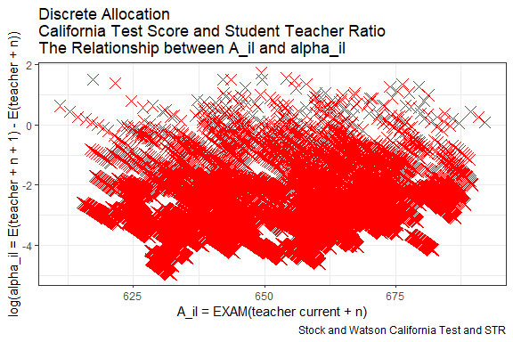

```r
# Generate alpha_i for each additional teacher
dfca_exmain <- dfca_exmain %>% mutate(alpha_il = theta_i*enrltot*((1/teachers_addl) - (1/(teachers_addl-1)))) %>%
                                   mutate(A_il = A_i + theta_i*(enrltot/(teachers_addl-1))) %>%
                                   rowid_to_column(var = "IDil")

# Graph of the Distribution of Alpha_i and A_i
scatter <- dfca_exmain %>% ggplot(aes(x=A_il)) +
      geom_point(aes(y=log(alpha_il)), size=4, shape=4, color="red") +
      geom_abline(intercept = 0, slope = 1) + # 45 degree line
      labs(title = paste0('Discrete Allocation\nCalifornia Test Score and Student Teacher Ratio\nThe Relationship between A_il and alpha_il'),
           x = 'A_il = EXAM(teacher current + n)',
           y = 'log(alpha_il = E(teacher + n + 1) - E(teacher + n))',
           caption = paste0('Stock and Watson California Test and STR')) +
      theme_bw()

print(scatter)
```

```r
# display
kable(dfca_exmain[0:75,]) %>%
  kable_styling(bootstrap_options = c("striped", "hover", "condensed", "responsive"))
```

| IDil | id | teachers | enrltot | A_i | theta_i | beta_i | i_d_l | teachers_addl | alpha_il | A_il |
| --- | --- | --- | --- | --- | --- | --- | --- | --- | --- | --- |
| 1 | 1 | 11 | 195 | 706.2218 | -0.8699505 | 0.002381 | 1 | 11 | 1.5421850 | 689.2578 |
| 2 | 1 | 11 | 195 | 706.2218 | -0.8699505 | 0.002381 | 2 | 12 | 1.2851542 | 690.8000 |
| 3 | 1 | 11 | 195 | 706.2218 | -0.8699505 | 0.002381 | 3 | 13 | 1.0874381 | 692.0851 |
| 4 | 2 | 11 | 240 | 673.2570 | -0.8699505 | 0.002381 | 1 | 11 | 1.8980738 | 652.3781 |
| 5 | 2 | 11 | 240 | 673.2570 | -0.8699505 | 0.002381 | 2 | 12 | 1.5817282 | 654.2762 |
| 6 | 2 | 11 | 240 | 673.2570 | -0.8699505 | 0.002381 | 3 | 13 | 1.3383854 | 655.8580 |
| 7 | 3 | 83 | 1550 | 657.0958 | -0.8699505 | 0.002381 | 1 | 83 | 0.1981227 | 640.6516 |
| 8 | 3 | 83 | 1550 | 657.0958 | -0.8699505 | 0.002381 | 2 | 84 | 0.1934055 | 640.8497 |
| 9 | 3 | 83 | 1550 | 657.0958 | -0.8699505 | 0.002381 | 3 | 85 | 0.1888548 | 641.0432 |
| 10 | 3 | 83 | 1550 | 657.0958 | -0.8699505 | 0.002381 | 4 | 86 | 0.1844628 | 641.2320 |
| 11 | 3 | 83 | 1550 | 657.0958 | -0.8699505 | 0.002381 | 5 | 87 | 0.1802223 | 641.4165 |
| 12 | 3 | 83 | 1550 | 657.0958 | -0.8699505 | 0.002381 | 6 | 88 | 0.1761263 | 641.5967 |
| 13 | 3 | 83 | 1550 | 657.0958 | -0.8699505 | 0.002381 | 7 | 89 | 0.1721684 | 641.7728 |
| 14 | 3 | 83 | 1550 | 657.0958 | -0.8699505 | 0.002381 | 8 | 90 | 0.1683425 | 641.9450 |
| 15 | 3 | 83 | 1550 | 657.0958 | -0.8699505 | 0.002381 | 9 | 91 | 0.1646426 | 642.1133 |
| 16 | 3 | 83 | 1550 | 657.0958 | -0.8699505 | 0.002381 | 10 | 92 | 0.1610635 | 642.2780 |
| 17 | 3 | 83 | 1550 | 657.0958 | -0.8699505 | 0.002381 | 11 | 93 | 0.1575997 | 642.4390 |
| 18 | 3 | 83 | 1550 | 657.0958 | -0.8699505 | 0.002381 | 12 | 94 | 0.1542465 | 642.5966 |
| 19 | 3 | 83 | 1550 | 657.0958 | -0.8699505 | 0.002381 | 13 | 95 | 0.1509992 | 642.7509 |
| 20 | 3 | 83 | 1550 | 657.0958 | -0.8699505 | 0.002381 | 14 | 96 | 0.1478534 | 642.9019 |
| 21 | 3 | 83 | 1550 | 657.0958 | -0.8699505 | 0.002381 | 15 | 97 | 0.1448049 | 643.0497 |
| 22 | 3 | 83 | 1550 | 657.0958 | -0.8699505 | 0.002381 | 16 | 98 | 0.1418497 | 643.1945 |
| 23 | 3 | 83 | 1550 | 657.0958 | -0.8699505 | 0.002381 | 17 | 99 | 0.1389841 | 643.3364 |
| 24 | 3 | 83 | 1550 | 657.0958 | -0.8699505 | 0.002381 | 18 | 100 | 0.1362044 | 643.4754 |
| 25 | 3 | 83 | 1550 | 657.0958 | -0.8699505 | 0.002381 | 19 | 101 | 0.1335073 | 643.6116 |
| 26 | 3 | 83 | 1550 | 657.0958 | -0.8699505 | 0.002381 | 20 | 102 | 0.1308895 | 643.7451 |
| 27 | 3 | 83 | 1550 | 657.0958 | -0.8699505 | 0.002381 | 21 | 103 | 0.1283479 | 643.8760 |
| 28 | 3 | 83 | 1550 | 657.0958 | -0.8699505 | 0.002381 | 22 | 104 | 0.1258797 | 644.0043 |
| 29 | 3 | 83 | 1550 | 657.0958 | -0.8699505 | 0.002381 | 23 | 105 | 0.1234820 | 644.1302 |
| 30 | 3 | 83 | 1550 | 657.0958 | -0.8699505 | 0.002381 | 24 | 106 | 0.1211521 | 644.2537 |
| 31 | 4 | 14 | 243 | 656.3883 | -0.8699505 | 0.002381 | 1 | 14 | 1.1615273 | 640.1270 |
| 32 | 4 | 14 | 243 | 656.3883 | -0.8699505 | 0.002381 | 2 | 15 | 1.0066570 | 641.2885 |
| 33 | 4 | 14 | 243 | 656.3883 | -0.8699505 | 0.002381 | 3 | 16 | 0.8808249 | 642.2952 |
| 34 | 4 | 14 | 243 | 656.3883 | -0.8699505 | 0.002381 | 4 | 17 | 0.7771984 | 643.1760 |
| 35 | 5 | 72 | 1335 | 655.5153 | -0.8699505 | 0.002381 | 1 | 72 | 0.2271878 | 639.1578 |
| 36 | 5 | 72 | 1335 | 655.5153 | -0.8699505 | 0.002381 | 2 | 73 | 0.2209635 | 639.3850 |
| 37 | 5 | 72 | 1335 | 655.5153 | -0.8699505 | 0.002381 | 3 | 74 | 0.2149915 | 639.6060 |
| 38 | 5 | 72 | 1335 | 655.5153 | -0.8699505 | 0.002381 | 4 | 75 | 0.2092584 | 639.8210 |
| 39 | 5 | 72 | 1335 | 655.5153 | -0.8699505 | 0.002381 | 5 | 76 | 0.2037516 | 640.0302 |
| 40 | 5 | 72 | 1335 | 655.5153 | -0.8699505 | 0.002381 | 6 | 77 | 0.1984593 | 640.2340 |
| 41 | 5 | 72 | 1335 | 655.5153 | -0.8699505 | 0.002381 | 7 | 78 | 0.1933706 | 640.4324 |
| 42 | 5 | 72 | 1335 | 655.5153 | -0.8699505 | 0.002381 | 8 | 79 | 0.1884752 | 640.6258 |
| 43 | 5 | 72 | 1335 | 655.5153 | -0.8699505 | 0.002381 | 9 | 80 | 0.1837633 | 640.8143 |
| 44 | 5 | 72 | 1335 | 655.5153 | -0.8699505 | 0.002381 | 10 | 81 | 0.1792259 | 640.9980 |
| 45 | 5 | 72 | 1335 | 655.5153 | -0.8699505 | 0.002381 | 11 | 82 | 0.1748546 | 641.1773 |
| 46 | 5 | 72 | 1335 | 655.5153 | -0.8699505 | 0.002381 | 12 | 83 | 0.1706412 | 641.3521 |
| 47 | 5 | 72 | 1335 | 655.5153 | -0.8699505 | 0.002381 | 13 | 84 | 0.1665783 | 641.5228 |
| 48 | 5 | 72 | 1335 | 655.5153 | -0.8699505 | 0.002381 | 14 | 85 | 0.1626588 | 641.6893 |
| 49 | 5 | 72 | 1335 | 655.5153 | -0.8699505 | 0.002381 | 15 | 86 | 0.1588761 | 641.8520 |
| 50 | 5 | 72 | 1335 | 655.5153 | -0.8699505 | 0.002381 | 16 | 87 | 0.1552237 | 642.0109 |
| 51 | 5 | 72 | 1335 | 655.5153 | -0.8699505 | 0.002381 | 17 | 88 | 0.1516959 | 642.1661 |
| 52 | 5 | 72 | 1335 | 655.5153 | -0.8699505 | 0.002381 | 18 | 89 | 0.1482870 | 642.3178 |
| 53 | 5 | 72 | 1335 | 655.5153 | -0.8699505 | 0.002381 | 19 | 90 | 0.1449918 | 642.4661 |
| 54 | 5 | 72 | 1335 | 655.5153 | -0.8699505 | 0.002381 | 20 | 91 | 0.1418051 | 642.6111 |
| 55 | 5 | 72 | 1335 | 655.5153 | -0.8699505 | 0.002381 | 21 | 92 | 0.1387224 | 642.7529 |
| 56 | 6 | 6 | 137 | 645.3442 | -0.8699505 | 0.002381 | 1 | 6 | 3.9727740 | 621.5075 |
| 57 | 7 | 10 | 195 | 629.8211 | -0.8699505 | 0.002381 | 1 | 10 | 1.8848928 | 610.9722 |
| 58 | 7 | 10 | 195 | 629.8211 | -0.8699505 | 0.002381 | 2 | 11 | 1.5421850 | 612.8571 |
| 59 | 7 | 10 | 195 | 629.8211 | -0.8699505 | 0.002381 | 3 | 12 | 1.2851542 | 614.3993 |
| 60 | 8 | 42 | 888 | 635.6090 | -0.8699505 | 0.002381 | 1 | 42 | 0.4486156 | 616.7671 |
| 61 | 8 | 42 | 888 | 635.6090 | -0.8699505 | 0.002381 | 2 | 43 | 0.4277498 | 617.2157 |
| 62 | 8 | 42 | 888 | 635.6090 | -0.8699505 | 0.002381 | 3 | 44 | 0.4083066 | 617.6435 |
| 63 | 8 | 42 | 888 | 635.6090 | -0.8699505 | 0.002381 | 4 | 45 | 0.3901596 | 618.0518 |
| 64 | 8 | 42 | 888 | 635.6090 | -0.8699505 | 0.002381 | 5 | 46 | 0.3731962 | 618.4419 |
| 65 | 8 | 42 | 888 | 635.6090 | -0.8699505 | 0.002381 | 6 | 47 | 0.3573155 | 618.8151 |
| 66 | 8 | 42 | 888 | 635.6090 | -0.8699505 | 0.002381 | 7 | 48 | 0.3424273 | 619.1725 |
| 67 | 8 | 42 | 888 | 635.6090 | -0.8699505 | 0.002381 | 8 | 49 | 0.3284507 | 619.5149 |
| 68 | 8 | 42 | 888 | 635.6090 | -0.8699505 | 0.002381 | 9 | 50 | 0.3153127 | 619.8433 |
| 69 | 8 | 42 | 888 | 635.6090 | -0.8699505 | 0.002381 | 10 | 51 | 0.3029475 | 620.1586 |
| 70 | 8 | 42 | 888 | 635.6090 | -0.8699505 | 0.002381 | 11 | 52 | 0.2912956 | 620.4616 |
| 71 | 8 | 42 | 888 | 635.6090 | -0.8699505 | 0.002381 | 12 | 53 | 0.2803034 | 620.7529 |
| 72 | 9 | 19 | 379 | 642.0002 | -0.8699505 | 0.002381 | 1 | 19 | 0.9640680 | 623.6829 |
| 73 | 9 | 19 | 379 | 642.0002 | -0.8699505 | 0.002381 | 2 | 20 | 0.8676612 | 624.6470 |
| 74 | 9 | 19 | 379 | 642.0002 | -0.8699505 | 0.002381 | 3 | 21 | 0.7850268 | 625.5146 |
| 75 | 9 | 19 | 379 | 642.0002 | -0.8699505 | 0.002381 | 4 | 22 | 0.7136607 | 626.2997 |

**Step 5**

Sort, and select top given total resource avaiable, The count the total allocation for each. This means to invoke the binary allocation function.

```r
# Optimal Targeting
ar_rho = c(-100, -0.001,  0.95)
ar_rho <- unique(ar_rho)
ls_bin_solu_all_rhos <-
  ffp_opt_anlyz_rhgin_bin(dfca_exmain, svr_id_i = 'IDil',
                          svr_A_i = 'A_il', svr_alpha_i = 'alpha_il', svr_beta_i = 'beta_i',
                          ar_rho = ar_rho,
                          svr_inpalc = 'opti_alloc_queue',
                          svr_expout = 'opti_exp_outcome')
```

```
## `id`Adding missing grouping variables: `id`
```

[output not shown]

[output cut: 102 more lines]

[output not shown]

```r
# Results from optimal targeting
df_all_rho <- ls_bin_solu_all_rhos$df_all_rho
df_all_rho_long <- ls_bin_solu_all_rhos$df_all_rho_long

# display
kable(df_all_rho[0:500,]) %>%
  kable_styling(bootstrap_options = c("striped", "hover", "condensed", "responsive"))
```

| IDil | A_il | alpha_il | beta_i | rank_min | rank_max | avg_rank | id.x | teachers | enrltot | A_i | theta_i | i_d_l | teachers_addl | id.y | rho_c1_rk | id.x.x | rho_c2_rk | id.y.y | rho_c3_rk |
| --- | --- | --- | --- | --- | --- | --- | --- | --- | --- | --- | --- | --- | --- | --- | --- | --- | --- | --- | --- |
| 1 | 689.2578 | 1.5421850 | 0.002381 | 12411 | 95 | 4202.33333 | 1 | 11 | 195 | 706.2218 | -0.8699505 | 1 | 11 | 1 | 12411 | 1 | 101 | 1 | 95 |
| 2 | 690.8000 | 1.2851542 | 0.002381 | 13408 | 130 | 4558.66667 | 1 | 11 | 195 | 706.2218 | -0.8699505 | 2 | 12 | 1 | 13408 | 1 | 138 | 1 | 130 |
| 3 | 692.0851 | 1.0874381 | 0.002381 | 14164 | 169 | 4840.00000 | 1 | 11 | 195 | 706.2218 | -0.8699505 | 3 | 13 | 1 | 14164 | 1 | 187 | 1 | 169 |
| 4 | 652.3781 | 1.8980738 | 0.002381 | 1545 | 62 | 556.33333 | 2 | 11 | 240 | 673.2570 | -0.8699505 | 1 | 11 | 2 | 1545 | 2 | 62 | 2 | 62 |
| 5 | 654.2762 | 1.5817282 | 0.002381 | 1969 | 89 | 716.66667 | 2 | 11 | 240 | 673.2570 | -0.8699505 | 2 | 12 | 2 | 1969 | 2 | 92 | 2 | 89 |
| 6 | 655.8580 | 1.3383854 | 0.002381 | 2475 | 119 | 905.66667 | 2 | 11 | 240 | 673.2570 | -0.8699505 | 3 | 13 | 2 | 2475 | 2 | 123 | 2 | 119 |
| 7 | 640.6516 | 0.1981227 | 0.002381 | 1801 | 1603 | 1682.00000 | 3 | 83 | 1550 | 657.0958 | -0.8699505 | 1 | 83 | 3 | 1801 | 3 | 1603 | 3 | 1642 |
| 8 | 640.8497 | 0.1934055 | 0.002381 | 1866 | 1641 | 1727.33333 | 3 | 83 | 1550 | 657.0958 | -0.8699505 | 2 | 84 | 3 | 1866 | 3 | 1641 | 3 | 1675 |
| 9 | 641.0432 | 0.1888548 | 0.002381 | 1926 | 1679 | 1774.00000 | 3 | 83 | 1550 | 657.0958 | -0.8699505 | 3 | 85 | 3 | 1926 | 3 | 1679 | 3 | 1717 |
| 10 | 641.2320 | 0.1844628 | 0.002381 | 1981 | 1721 | 1820.00000 | 3 | 83 | 1550 | 657.0958 | -0.8699505 | 4 | 86 | 3 | 1981 | 3 | 1721 | 3 | 1758 |
| 11 | 641.4165 | 0.1802223 | 0.002381 | 2038 | 1764 | 1866.66667 | 3 | 83 | 1550 | 657.0958 | -0.8699505 | 5 | 87 | 3 | 2038 | 3 | 1764 | 3 | 1798 |
| 12 | 641.5967 | 0.1761263 | 0.002381 | 2093 | 1807 | 1915.00000 | 3 | 83 | 1550 | 657.0958 | -0.8699505 | 6 | 88 | 3 | 2093 | 3 | 1807 | 3 | 1845 |
| 13 | 641.7728 | 0.1721684 | 0.002381 | 2160 | 1852 | 1966.00000 | 3 | 83 | 1550 | 657.0958 | -0.8699505 | 7 | 89 | 3 | 2160 | 3 | 1852 | 3 | 1886 |
| 14 | 641.9450 | 0.1683425 | 0.002381 | 2222 | 1895 | 2016.66667 | 3 | 83 | 1550 | 657.0958 | -0.8699505 | 8 | 90 | 3 | 2222 | 3 | 1895 | 3 | 1933 |
| 15 | 642.1133 | 0.1646426 | 0.002381 | 2278 | 1942 | 2067.66667 | 3 | 83 | 1550 | 657.0958 | -0.8699505 | 9 | 91 | 3 | 2278 | 3 | 1942 | 3 | 1983 |
| 16 | 642.2780 | 0.1610635 | 0.002381 | 2349 | 1997 | 2126.66667 | 3 | 83 | 1550 | 657.0958 | -0.8699505 | 10 | 92 | 3 | 2349 | 3 | 1997 | 3 | 2034 |
| 17 | 642.4390 | 0.1575997 | 0.002381 | 2421 | 2046 | 2183.00000 | 3 | 83 | 1550 | 657.0958 | -0.8699505 | 11 | 93 | 3 | 2421 | 3 | 2046 | 3 | 2082 |
| 18 | 642.5966 | 0.1542465 | 0.002381 | 2489 | 2097 | 2240.00000 | 3 | 83 | 1550 | 657.0958 | -0.8699505 | 12 | 94 | 3 | 2489 | 3 | 2097 | 3 | 2134 |
| 19 | 642.7509 | 0.1509992 | 0.002381 | 2572 | 2146 | 2302.33333 | 3 | 83 | 1550 | 657.0958 | -0.8699505 | 13 | 95 | 3 | 2572 | 3 | 2146 | 3 | 2189 |
| 20 | 642.9019 | 0.1478534 | 0.002381 | 2658 | 2200 | 2366.00000 | 3 | 83 | 1550 | 657.0958 | -0.8699505 | 14 | 96 | 3 | 2658 | 3 | 2200 | 3 | 2240 |
| 21 | 643.0497 | 0.1448049 | 0.002381 | 2741 | 2255 | 2429.66667 | 3 | 83 | 1550 | 657.0958 | -0.8699505 | 15 | 97 | 3 | 2741 | 3 | 2255 | 3 | 2293 |
| 22 | 643.1945 | 0.1418497 | 0.002381 | 2819 | 2309 | 2491.33333 | 3 | 83 | 1550 | 657.0958 | -0.8699505 | 16 | 98 | 3 | 2819 | 3 | 2309 | 3 | 2346 |
| 23 | 643.3364 | 0.1389841 | 0.002381 | 2908 | 2364 | 2560.00000 | 3 | 83 | 1550 | 657.0958 | -0.8699505 | 17 | 99 | 3 | 2908 | 3 | 2364 | 3 | 2408 |
| 24 | 643.4754 | 0.1362044 | 0.002381 | 3007 | 2420 | 2631.33333 | 3 | 83 | 1550 | 657.0958 | -0.8699505 | 18 | 100 | 3 | 3007 | 3 | 2420 | 3 | 2467 |
| 25 | 643.6116 | 0.1335073 | 0.002381 | 3096 | 2484 | 2702.33333 | 3 | 83 | 1550 | 657.0958 | -0.8699505 | 19 | 101 | 3 | 3096 | 3 | 2484 | 3 | 2527 |
| 26 | 643.7451 | 0.1308895 | 0.002381 | 3200 | 2547 | 2780.33333 | 3 | 83 | 1550 | 657.0958 | -0.8699505 | 20 | 102 | 3 | 3200 | 3 | 2547 | 3 | 2594 |
| 27 | 643.8760 | 0.1283479 | 0.002381 | 3307 | 2613 | 2861.00000 | 3 | 83 | 1550 | 657.0958 | -0.8699505 | 21 | 103 | 3 | 3307 | 3 | 2613 | 3 | 2663 |
| 28 | 644.0043 | 0.1258797 | 0.002381 | 3410 | 2686 | 2943.00000 | 3 | 83 | 1550 | 657.0958 | -0.8699505 | 22 | 104 | 3 | 3410 | 3 | 2686 | 3 | 2733 |
| 29 | 644.1302 | 0.1234820 | 0.002381 | 3506 | 2761 | 3025.00000 | 3 | 83 | 1550 | 657.0958 | -0.8699505 | 23 | 105 | 3 | 3506 | 3 | 2761 | 3 | 2808 |
| 30 | 644.2537 | 0.1211521 | 0.002381 | 3601 | 2829 | 3103.66667 | 3 | 83 | 1550 | 657.0958 | -0.8699505 | 24 | 106 | 3 | 3601 | 3 | 2829 | 3 | 2881 |

[output cut: 470 more lines]

Back to dataframe mt_ori, incorporate into that, but do and shift for each rho.

```r
# Child Weight
```